# Homework 2 P3

Amy Ly

2/9/2023

## Problem Context

The data below are launch temperatures (degrees Farenheit) and an indicator o O-ring failures for 24 space shuttle launches prior to the space shuttle Challenger disaster of January 27, 1986. Note that 0 indicates “No Failure” while 1 indicates “Failure”

```r
data <-
  data.frame(temperature = c(53, 56, 57, 63, 66, 67, 67, 67,
                             68, 69, 70, 70, 70, 70, 72, 73,
                             75, 75, 76, 76, 78, 79, 80, 81),
                  failure = c(1, 1, 1, 0, 0, 0, 0, 0,
                              0, 0, 0, 1, 1, 1, 0, 0,
                              0, 1, 0, 0, 0, 0, 0, 0))

head(data)
```

```
##   temperature failure
## 1          53       1
## 2          56       1
## 3          57       1
## 4          63       0
## 5          66       0
## 6          67       0
```

### Exploratory Data Analysis

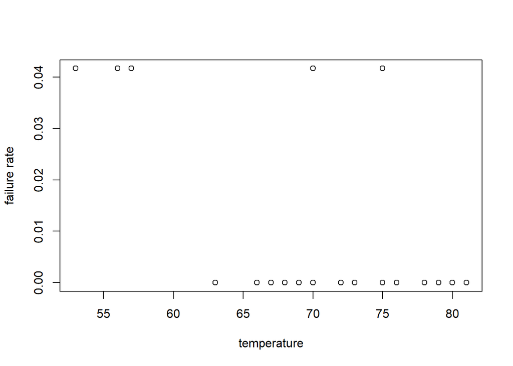

```r
plot(data$temperature, data$failure/nrow(data),
     xlab="temperature", ylab="failure rate")
```

Visualize the data

### Part a

Fit the logistic regression of Failure on Temperature.

The estimated coefficients and their standard errors are then summarized below.

```r
##  One column binary response

n <- nrow(data)
y0=as.numeric(data$failure)

X=matrix(1,n,2)
X[,2]=data$temperature


#### Fit logistic regressions

logit.y = glm(y0~data$temperature, family=binomial)

summary(logit.y)
```

```
##
## Call:
## glm(formula = y0 ~ data$temperature, family = binomial)
##
## Deviance Residuals:
##     Min       1Q   Median       3Q      Max
## -1.2125  -0.8253  -0.4706   0.5907   2.0512
##
## Coefficients:
##                  Estimate Std. Error z value Pr(>|z|)
## (Intercept)      10.87535    5.70291   1.907   0.0565 .
## data$temperature -0.17132    0.08344  -2.053   0.0400 *
## ---
## Signif. codes:  0 '***' 0.001 '**' 0.01 '*' 0.05 '.' 0.1 ' ' 1
##
## (Dispersion parameter for binomial family taken to be 1)
##
##     Null deviance: 28.975  on 23  degrees of freedom
## Residual deviance: 23.030  on 22  degrees of freedom
## AIC: 27.03
##
## Number of Fisher Scoring iterations: 4
```

### Part b

Test whether the coefficient of Temperature is 0 using Wald’s test. Report a one-sided p-value where the alternative hypothesis is that the coefficient is negative (that the odds of failure decreases with increasing temperature).

```r
logit.y$coef
```

```
##      (Intercept) data$temperature
##       10.8753491       -0.1713205
```

```r
V = vcov(logit.y)

#Wald test

Wald <-(logit.y$coef[2]-0)/sqrt(solve(V)[2,2])

Wald
```

```
## data$temperature
##     -0.001297033
```

```r
p.val <- pnorm(Wald, lower.tail=TRUE)

p.val
```

```
## data$temperature
##        0.4994826
```

### Part c

Give the 95% confidence interval for the coefficient of Temperature.

```r
#95% CI for beta
c(logit.y$coef[2]-1.96*sqrt(V[2,2]),
  logit.y$coef[2]+1.96*sqrt(V[2,2]))
```

```
## data$temperature data$temperature
##     -0.334860261     -0.007780741
```

The 95% confidence interval does not contain 0, which indicates that there is a possibility that the coefficient is negative.

### Part d

What is the estimated probability of failure at 31 degrees Farenheit?

```r
# At temp = 31, parameter theta = alpha + beta*31
theta_hat = logit.y$coef[1]+logit.y$coef[2]*31

exp(theta_hat) # Predicted survival odds
```

```
## (Intercept)
##    260.9721
```

```r
exp(theta_hat)/(1+exp(theta_hat)) # Predicted survival probability
```

```
## (Intercept)
##   0.9961828
```

At 31 degrees Farenheit, the probability of O-ring failure is about 99.6%.